# Tissue-expressed genes

Marta del Olmo

2/2/2021

**This document explores the rhythmicity of genes in epidermis and dermis. We check how many rhythmic genes there are in each tissue, what their phases and amplitudes are, how they correlate between skin tissues, etc. Note that all these ‘postporcessing’ analyses are done with the null hypothesis $H_0$ being that tissue and subjects are independent factors, and that rhythms in dermis are the same as rhythms in epidermis. No sex information was included in the hypothesis testing so far.**

## **1. Comparison of rhythmic (and expressed) genes in Dermis vs. Epidermis**

Set cutoffs (like in BA’s script)

```r
fdr_cutoff <- 0.05
amp_cutoff <- log2(1 + 0.2)
```

Load the raw data and the results of the fits ($H_0$ like BA’s script, without sex information)

```r
yave <- readRDS("visualize/data/rawdata.rds") #raw data after normalization and QC
results <- readRDS("visualize/data/results.rds") #results of fits (after lmFit, eBayes, topTable)
results %<>%
  dplyr::mutate(A_D = sqrt(tissueD_inphase^2 + tissueD_outphase^2),
  A_E = sqrt(tissueE_inphase^2 + tissueE_outphase^2),
  phaseD = atan2(tissueD_outphase, tissueD_inphase)*12/pi,
  phaseE = atan2(tissueE_outphase, tissueE_inphase)*12/pi)
```

Now some exploratory analysis:

1. **Plot 1**: First we illustrate the overlap of rhythmic genes in dermis vs. epidermis (based on our cutoffs)
   - 1072 rhythmic genes in dermis OR epidermis
   - 206 rhythmic genes in both
   - 251 genes rhythmic only in D
   - 615 genes rhythmic only in E
2. **Plot 2**: Comparison of amplitudes of rhythmic genes in epidermis vs dermis. Note that genes that are rhythmic in *either-or* tissue are plotted here (i.e., the 1072 genes). If we want to compare the amplitudes of genes that are rhythmic in both tissues (206), substitute `some_rhythm` for `both_rhythm`
3. **Plot 3**: Comparison of phases of rhythmic genes in epidermis vs dermis. Note that genes that are rhythmic in *either-or* tissue are plotted here (i.e., the 1072 genes). If we want to compare the phases of genes that are rhythmic in both tissues (206), substitute `some_rhythm` for `both_rhythm`
   - Phases clusted mainly in two peaks: at around 6 and -6 (both with `some_rhythm` and `both_rhythm`)

I think I don’t completely understand the FDR in `results` -> How can I check if a gene is expressed in epidermis or if it is expressed in dermis? Relates to the question in the next line of code `expressed`

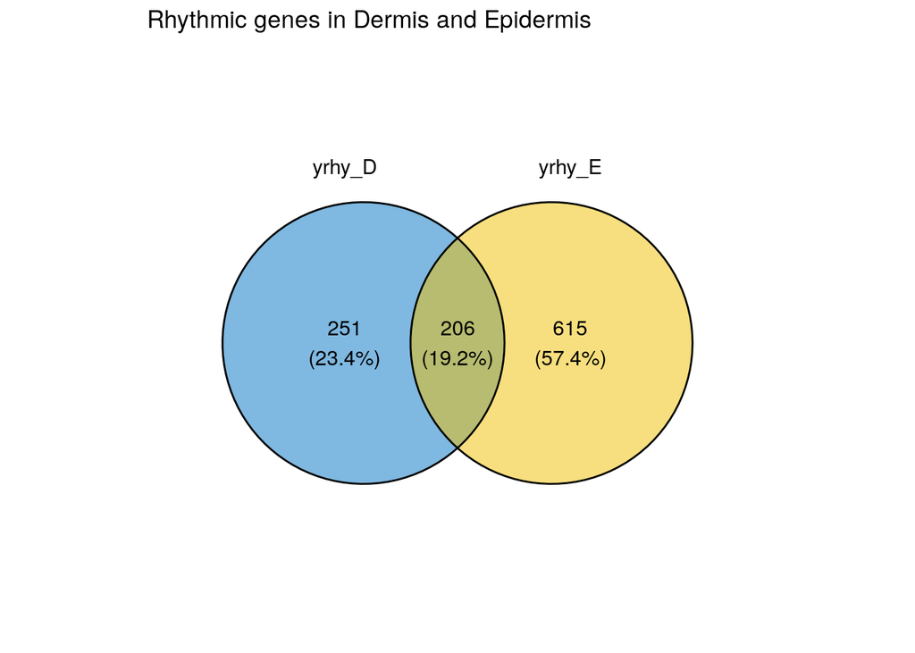

```r
expressed   <- dplyr::filter(results, adj_P_Val < fdr_cutoff) %$% ProbeName
  #But how do I know if they are expressed in D or E?

both_rhythm <- dplyr::filter(results, A_D>amp_cutoff & A_E>amp_cutoff & adj_P_Val<fdr_cutoff) %$% ProbeName
some_rhythm <- dplyr::filter(results, pmax(A_D, A_E) > amp_cutoff & adj_P_Val < fdr_cutoff) %$% ProbeName
rhythm_D <- results[which(results$ProbeName %in% some_rhythm), ] %>% filter(A_D > amp_cutoff) %$% ProbeName
rhythm_E <- results[which(results$ProbeName %in% some_rhythm), ] %>% filter(A_E > amp_cutoff) %$% ProbeName

yrhy <- list(yrhy_D = yave$genes$ProbeName[yave$genes$ProbeName %in% rhythm_D],
             yrhy_E = yave$genes$ProbeName[yave$genes$ProbeName %in% rhythm_E])

# ----- Venn diagram of rhythmic (expressed) genes in Dermis and Epidermis (either-or) -------
plot_Venn_compare_rhy <- ggvenn(yrhy, fill_color = c("#0073C2FF", "#EFC000FF"),
                                stroke_size = 0.5, set_name_size = 4) +
  ggtitle('Rhythmic genes in Dermis and Epidermis')

if (!file.exists("figures/Venn_compare_rhy.pdf")){
  plot_Venn_compare_rhy %>% ggsave("figures/Venn_compare_rhy.pdf", .)
}
plot_Venn_compare_rhy
```

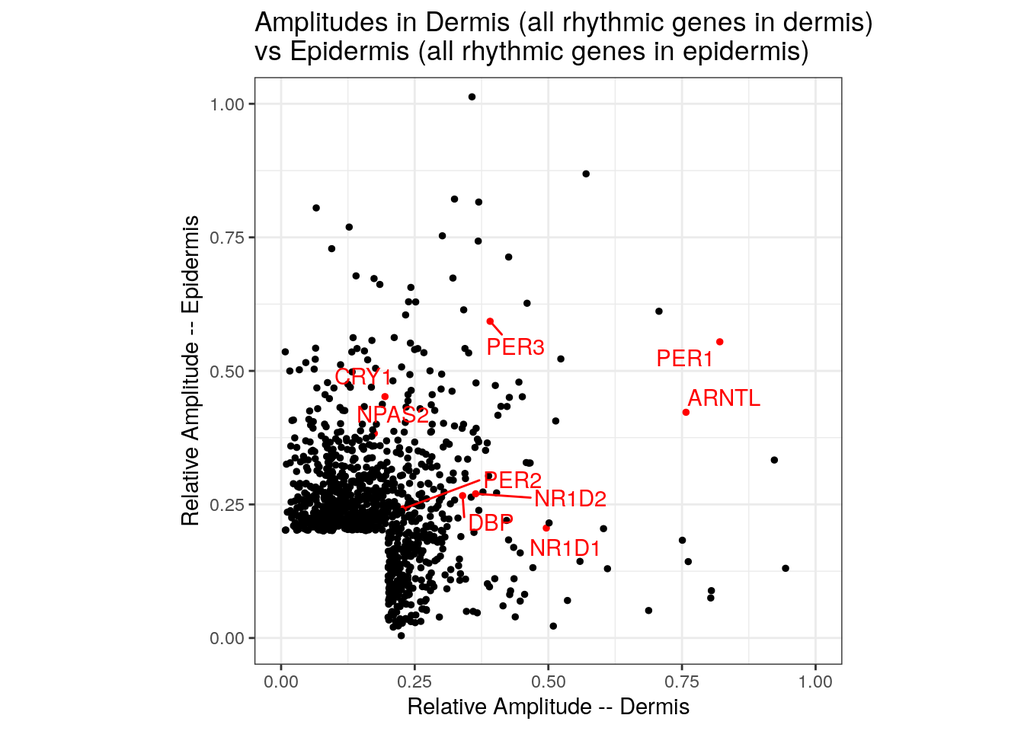

```r
# ----- Comparison of amplitudes of the 1072 rhythmic genes in dermis OR epidermis, emphasis on clock genes ----
clock_genes <- c("PER1","PER2","PER3", "CRY1", "CRY2", "NR1D1", "NR1D2", "ARNTL", "ARNTL2", "CLOCK",
                 "NPAS2","RORA","RORB","RORC", "CSNK1D", "CSNK1E", "DBP")

plot_Amplitude_compare <- ggplot(data = dplyr::filter(results, ProbeName %in% some_rhythm),
                                 aes(x=2^A_D-1, y=2^A_E-1)) + #amps are in log2
  geom_point(aes(color=Symbol %in% clock_genes), size=1) +
  geom_text_repel(aes(label=ifelse(Symbol %in% clock_genes, as.character(Symbol), "")), color="red",
                  max.overlaps=Inf, box.padding = 0.5) +
  scale_color_manual(values=c("black","red")) +
  theme_bw() + theme(aspect.ratio = 1, legend.position = "none") + coord_cartesian(xlim=c(0,1), ylim = c(0,1)) +
  xlab("Relative Amplitude -- Dermis") + ylab("Relative Amplitude -- Epidermis") +
  ggtitle("Amplitudes in Dermis (all rhythmic genes in dermis)\nvs Epidermis (all rhythmic genes in epidermis)")

if (!file.exists("figures/Amplitude_compare.pdf")){
  plot_Amplitude_compare %>% ggsave("figures/Amplitude_compare.pdf", .)
}
plot_Amplitude_compare
```

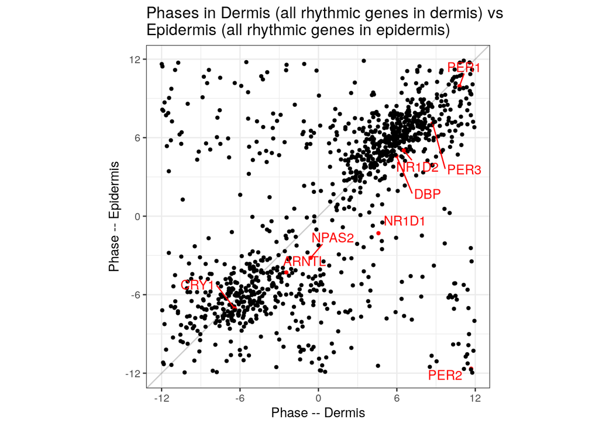

```r
# ----- Comparison of phases of the 1072 rhythmic genes in dermis OR epidermis, emphasis on clock genes -----
plot_Phase_compare <- ggplot(data = dplyr::filter(results, ProbeName %in% some_rhythm),
                             aes(x=phaseD, y=phaseE)) +
  geom_point(aes(color=Symbol %in% clock_genes), size=1) +
  geom_text_repel(aes(label=ifelse(Symbol %in% clock_genes, as.character(Symbol), "")), color="red",
                  max.overlaps=Inf, box.padding = 0.5) +
  scale_color_manual(values=c("black","red")) +
  theme_bw() + theme(aspect.ratio = 1, legend.position = "none") + geom_abline(slope = 1, alpha=0.2) +
  scale_x_continuous(breaks = seq(-12,12,by = 6)) +
  scale_y_continuous(breaks = seq(-12,12,by = 6)) +
  xlab("Phase -- Dermis") + ylab("Phase -- Epidermis")+
  ggtitle("Phases in Dermis (all rhythmic genes in dermis) vs\nEpidermis (all rhythmic genes in epidermis)")

if (!file.exists("figures/Phase_compare.pdf")){
  plot_Phase_compare %>% ggsave("figures/Phase_compare.pdf", .)
}
plot_Phase_compare
```

## **2. GO and Pathway Analysis in tissues**

### **2.1. Of genes that are rhythmic in either-or (together)**

Double check that the code of the plot makes sense. x axis is percentage of differentially expressed `DE` genes (with respect to all of the genes enriched for a term `N`) whereas the size of the circle shows the total number of `DE`

GO/KEGG analysis of genes that are rhythmic in dermis or epidermis (not making distinction) -> amp $>$ `amp_cutoff` (either-or), fdr $<$ `fdr_cutoff`

- GO enrichment: circulatory system, rhythmic processes
  - Analysis done with rhythmic genes in either-or
  - p values in the order of 10e-4 -> not super significant?
- KEGG enrichment: rhythmic processes, immune-related pathways
  - Analysis done with rhythmic genes in either-or

```r
g <- goana(yave[yave$genes$ProbeName %in% some_rhythm,]$genes$EntrezID, universe = yave$genes$EntrezID)
topGO(g, n=20, truncate.term = "42") # super significant terms have p values in the order of 10e-8
```

```
##                                                  Term Ont    N  DE         P.DE
## GO:0007589                       body fluid secretion  BP   55  16 2.406608e-05
## GO:0005887      integral component of plasma membrane  CC  771 103 6.984727e-05
## GO:0060137 maternal process involved in parturitio...  BP    4   4 7.317063e-05
## GO:0031226     intrinsic component of plasma membrane  CC  818 108 7.528005e-05
## GO:0032922    circadian regulation of gene expression  BP   45  13 1.495402e-04
## GO:0051239 regulation of multicellular organismal ...  BP 1948 224 1.551022e-04
## GO:0071384 cellular response to corticosteroid sti...  BP   40  12 1.800696e-04
## GO:0010893 positive regulation of steroid biosynth...  BP   11   6 1.909614e-04
## GO:0003018     vascular process in circulatory system  BP   98  21 2.033105e-04
## GO:0005520         insulin-like growth factor binding  MF   20   8 2.406065e-04
## GO:0097199 cysteine-type endopeptidase activity in...  MF    8   5 2.976897e-04
## GO:0010273               detoxification of copper ion  BP    8   5 2.976897e-04
## GO:1990169              stress response to copper ion  BP    8   5 2.976897e-04
## GO:0042749 regulation of circadian sleep/wake cycl...  BP    5   4 3.388410e-04
## GO:0071548                  response to dexamethasone  BP   26   9 3.537060e-04
## GO:0009605              response to external stimulus  BP 1404 166 3.561053e-04
## GO:0071385 cellular response to glucocorticoid sti...  BP   37  11 3.638610e-04
## GO:0045892 negative regulation of transcription, D...  BP  826 105 4.051028e-04
## GO:2000351 regulation of endothelial cell apoptoti...  BP   27   9 4.873782e-04
## GO:1903507 negative regulation of nucleic acid-tem...  BP  859 108 5.034471e-04
```

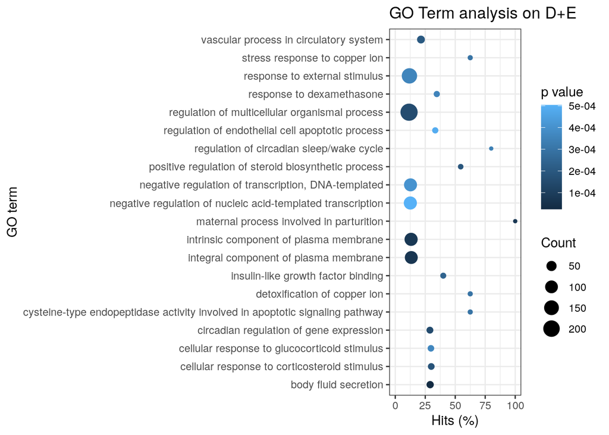

```r
g %>% top_n(20, wt=-P.DE) %>% mutate(hits=DE*100/N) %>%
    ggplot(aes(x=hits, y=Term, colour=P.DE, size=DE)) +
        geom_point() +
        expand_limits(x=0) +
        labs(x="Hits (%)", y="GO term", colour="p value", size="Count") +
    ggtitle("GO Term analysis on D+E") +
  theme_bw()
```

```r
k <- kegga(yave[yave$genes$ProbeName %in% some_rhythm,]$genes$EntrezID, universe = yave$genes$EntrezID)
topKEGG(k, n=20, truncate.path = "42")
```

```
##                                                  Pathway   N DE         P.DE
## path:hsa04710                           Circadian rhythm  22  8 0.0005156785
## path:hsa04933 AGE-RAGE signaling pathway in diabetic ...  74 15 0.0028236839
## path:hsa05230        Central carbon metabolism in cancer  52 11 0.0071005985
## path:hsa05418     Fluid shear stress and atherosclerosis 105 18 0.0074662295
## path:hsa04610        Complement and coagulation cascades  46 10 0.0082571026
## path:hsa04080    Neuroactive ligand-receptor interaction 108 18 0.0099759332
## path:hsa04061 Viral protein interaction with cytokine...  43  9 0.0152761846
## path:hsa05146                                 Amoebiasis  59 11 0.0181826167
## path:hsa04066                    HIF-1 signaling pathway  75 13 0.0193378129
## path:hsa04668                      TNF signaling pathway  83 14 0.0194829717
## path:hsa05202    Transcriptional misregulation in cancer 133 20 0.0203065534
## path:hsa05144                                    Malaria  31  7 0.0208192117
## path:hsa04919          Thyroid hormone signaling pathway  92 15 0.0212934329
## path:hsa04151                 PI3K-Akt signaling pathway 232 31 0.0236770278
## path:hsa04916                              Melanogenesis  70 12 0.0260411865
## path:hsa04750 Inflammatory mediator regulation of TRP...  63 11 0.0285695457
## path:hsa04929                             GnRH secretion  33  7 0.0287904446
## path:hsa05134                              Legionellosis  41  8 0.0319970605
## path:hsa03440                   Homologous recombination  34  7 0.0334572536
## path:hsa04215               Apoptosis - multiple species  27  6 0.0338749642
```

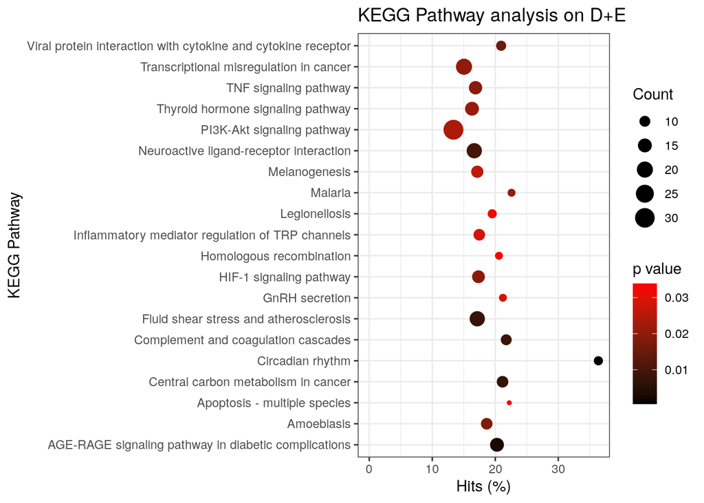

```r
k %>% top_n(20, wt=-P.DE) %>% mutate(hits=DE*100/N) %>%
    ggplot(aes(x=hits, y=Pathway, colour=P.DE, size=DE)) +
        geom_point() +
        expand_limits(x=0) +
        labs(x="Hits (%)", y="KEGG Pathway", colour="p value", size="Count") +
  scale_color_gradient(low="black", high="red") +
  ggtitle("KEGG Pathway analysis on D+E") +
  theme_bw()
```

### **2.2. Of genes rhythmic in one or another (separate)**

GO/KEGG analysis of genes that are rhythmic in dermis vs. GO analysis of genes that are rhythmic in epidermis (separate) -> amp $>$ `amp_cutoff` (either-or), fdr $<$ `fdr_cutoff`

- GO enrichment in E: rhythmic processes, immune system, stress responses, secretion
  - Analysis done with rhythmic genes in E
  - p values in the order of 10e-5 -> not super significant?
- GO enrichment in D: DNA binding, transcriptional regulation, circadian, regulation of secretion/uptake, rhythmic processes
  - Analysis done with rhythmic genes in D
  - p values in the order of 10e-5 -> not super significant?
- KEGG enrichment in E: rhythmic pathways, cancer-related pathways
  - Analysis done with rhythmic genes in E
- KEGG enrichment in D: immune-related pathways, rhythmic pathways
  - Analysis done with rhythmic genes in D

```r
# -------------- GO analysis -----------------
g_D <- goana(yave[yave$genes$ProbeName %in% rhythm_D,]$genes$EntrezID, universe = yave$genes$EntrezID)
g_E <- goana(yave[yave$genes$ProbeName %in% rhythm_E,]$genes$EntrezID, universe = yave$genes$EntrezID)

topGO(g_D, n=20, truncate.term = "42") # super significant terms have p values in the order of 10e-8
```

```
##                                                  Term Ont    N DE         P.DE
## GO:0001533                         cornified envelope  CC   39  9 1.585404e-05
## GO:0030545                receptor regulator activity  MF  205 21 6.015700e-05
## GO:0048545                response to steroid hormone  BP  257 24 8.120855e-05
## GO:0009605              response to external stimulus  BP 1404 83 8.740919e-05
## GO:0050796            regulation of insulin secretion  BP  109 14 9.453877e-05
## GO:0045934 negative regulation of nucleobase-conta...  BP 1011 64 9.472808e-05
## GO:0090276    regulation of peptide hormone secretion  BP  123 15 9.787238e-05
## GO:0044212 transcription regulatory region DNA bin...  MF  581 42 1.045720e-04
## GO:0001067     regulatory region nucleic acid binding  MF  582 42 1.086396e-04
## GO:0003690                double-stranded DNA binding  MF  605 43 1.264977e-04
## GO:0009914                          hormone transport  BP  186 19 1.390278e-04
## GO:0031424                             keratinization  BP   87 12 1.492112e-04
## GO:0000976 transcription regulatory region sequenc...  MF  498 37 1.576094e-04
## GO:0048512                         circadian behavior  BP   22  6 1.593237e-04
## GO:1990837 sequence-specific double-stranded DNA b...  MF  540 39 1.890514e-04
## GO:0048018                   receptor ligand activity  MF  191 19 1.968903e-04
## GO:0014070        response to organic cyclic compound  BP  560 40 1.971323e-04
## GO:0000122 negative regulation of transcription by...  BP  580 41 2.044922e-04
## GO:0001227 DNA-binding transcription repressor act...  MF  161 17 2.076912e-04
## GO:0007622                          rhythmic behavior  BP   23  6 2.084322e-04
```

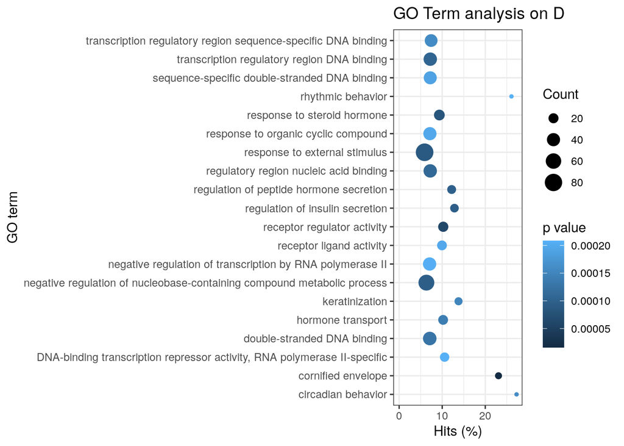

```r
g_D %>% top_n(20, wt=-P.DE) %>% mutate(hits=DE*100/N) %>%
    ggplot(aes(x=hits, y=Term, colour=P.DE, size=DE)) +
        geom_point() +
        expand_limits(x=0) +
        labs(x="Hits (%)", y="GO term", colour="p value", size="Count") +
  ggtitle("GO Term analysis on D") +
  theme_bw()
```

```r
topGO(g_E, n=20, truncate.term = "42")
```

```
##                                                  Term Ont   N DE         P.DE
## GO:0032922    circadian regulation of gene expression  BP  45 13 9.062963e-06
## GO:0010273               detoxification of copper ion  BP   8  5 8.287381e-05
## GO:1990169              stress response to copper ion  BP   8  5 8.287381e-05
## GO:0007623                           circadian rhythm  BP 120 21 9.648830e-05
## GO:0031226     intrinsic component of plasma membrane  CC 818 86 1.163361e-04
## GO:0042749 regulation of circadian sleep/wake cycl...  BP   5  4 1.185512e-04
## GO:0048641 regulation of skeletal muscle tissue de...  BP  30  9 1.598219e-04
## GO:0061687       detoxification of inorganic compound  BP   9  5 1.755649e-04
## GO:0005887      integral component of plasma membrane  CC 771 81 1.896202e-04
## GO:0002689 negative regulation of leukocyte chemot...  BP  10  5 3.306387e-04
## GO:0097501               stress response to metal ion  BP  10  5 3.306387e-04
## GO:0042752             regulation of circadian rhythm  BP  62 13 3.350824e-04
## GO:0015562 efflux transmembrane transporter activi...  MF   3  3 3.555314e-04
## GO:0007589                       body fluid secretion  BP  55 12 3.826614e-04
## GO:0035914       skeletal muscle cell differentiation  BP  41 10 4.529185e-04
## GO:1901861    regulation of muscle tissue development  BP  90 16 5.296151e-04
## GO:0071294              cellular response to zinc ion  BP  11  5 5.708606e-04
## GO:0048512                         circadian behavior  BP  22  7 5.835619e-04
## GO:0048511                           rhythmic process  BP 176 25 6.532294e-04
## GO:0002686 negative regulation of leukocyte migrat...  BP  29  8 6.946767e-04
```

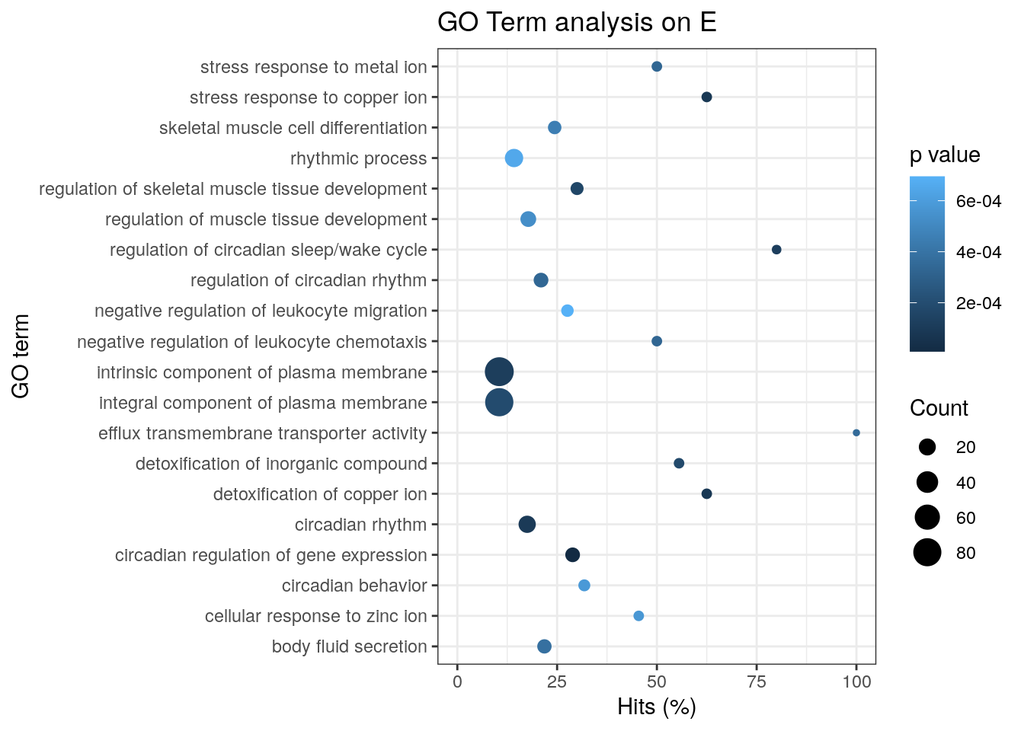

```r
g_E %>% top_n(20, wt=-P.DE) %>% mutate(hits=DE*100/N) %>%
    ggplot(aes(x=hits, y=Term, colour=P.DE, size=DE)) +
        geom_point() +
        expand_limits(x=0) +
        labs(x="Hits (%)", y="GO term", colour="p value", size="Count") +
  ggtitle("GO Term analysis on E") +
  theme_bw()
```

```r
# -------------- KEGG analysis -----------------
k_D <- kegga(yave[yave$genes$ProbeName %in% rhythm_D,]$genes$EntrezID, universe = yave$genes$EntrezID)
k_E <- kegga(yave[yave$genes$ProbeName %in% rhythm_E,]$genes$EntrezID, universe = yave$genes$EntrezID)

topKEGG(k_D, n=20, truncate.path = "42")
```

```
##                                                  Pathway   N DE         P.DE
## path:hsa04668                      TNF signaling pathway  83 12 9.382222e-05
## path:hsa04933 AGE-RAGE signaling pathway in diabetic ...  74 10 6.197626e-04
## path:hsa04080    Neuroactive ligand-receptor interaction 108 12 1.110026e-03
## path:hsa05144                                    Malaria  31  6 1.161908e-03
## path:hsa04710                           Circadian rhythm  22  5 1.413548e-03
## path:hsa05143                    African trypanosomiasis  16  4 2.986288e-03
## path:hsa04061 Viral protein interaction with cytokine...  43  6 6.458040e-03
## path:hsa01524                   Platinum drug resistance  57  7 6.844792e-03
## path:hsa05146                                 Amoebiasis  59  7 8.258337e-03
## path:hsa04973      Carbohydrate digestion and absorption  21  4 8.401595e-03
## path:hsa05142                             Chagas disease  61  7 9.875806e-03
## path:hsa04930                  Type II diabetes mellitus  26  4 1.797544e-02
## path:hsa04215               Apoptosis - multiple species  27  4 2.046093e-02
## path:hsa05168           Herpes simplex virus 1 infection 329 21 2.072444e-02
## path:hsa05134                              Legionellosis  41  5 2.180462e-02
## path:hsa05418     Fluid shear stress and atherosclerosis 105  9 2.281868e-02
## path:hsa04625 C-type lectin receptor signaling pathwa...  72  7 2.310027e-02
## path:hsa04150                     mTOR signaling pathway 113  9 3.454120e-02
## path:hsa04961 Endocrine and other factor-regulated ca...  32  4 3.596140e-02
## path:hsa04750 Inflammatory mediator regulation of TRP...  63  6 3.739257e-02
```

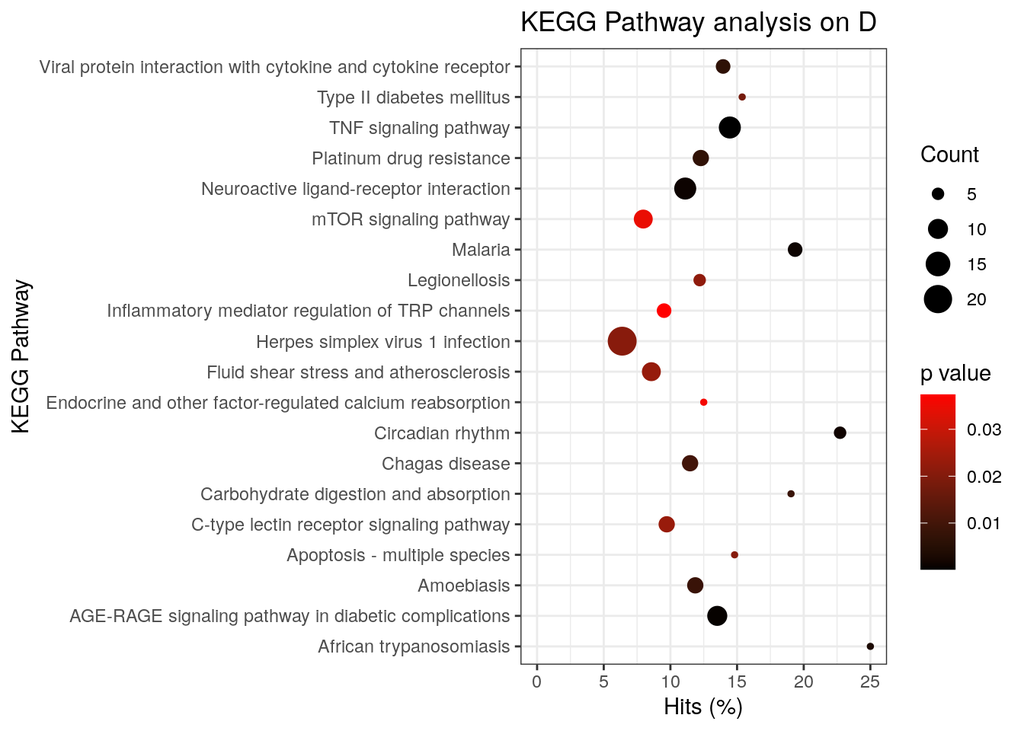

```r
k_D %>% top_n(20, wt=-P.DE) %>% mutate(hits=DE*100/N) %>%
    ggplot(aes(x=hits, y=Pathway, colour=P.DE, size=DE)) +
        geom_point() +
        expand_limits(x=0) +
        labs(x="Hits (%)", y="KEGG Pathway", colour="p value", size="Count") +
  scale_color_gradient(low="black", high="red") +
  ggtitle("KEGG Pathway analysis on D") +
  theme_bw()
```

```r
topKEGG(k_E, n=20, truncate.path = "42")
```

```
##                                                  Pathway   N DE         P.DE
## path:hsa04710                           Circadian rhythm  22  8 8.065866e-05
## path:hsa01230                Biosynthesis of amino acids  52  9 1.010652e-02
## path:hsa05230        Central carbon metabolism in cancer  52  9 1.010652e-02
## path:hsa05202    Transcriptional misregulation in cancer 133 17 1.277251e-02
## path:hsa04978                         Mineral absorption  39  7 1.837194e-02
## path:hsa00601 Glycosphingolipid biosynthesis - lacto ...  16  4 2.298043e-02
## path:hsa00051            Fructose and mannose metabolism  24  5 2.431773e-02
## path:hsa03440                   Homologous recombination  34  6 3.042922e-02
## path:hsa04610        Complement and coagulation cascades  46  7 4.177688e-02
## path:hsa05206                        MicroRNAs in cancer 132 15 4.679316e-02
## path:hsa04744                          Phototransduction  12  3 4.825188e-02
## path:hsa00450                  Selenocompound metabolism  12  3 4.825188e-02
## path:hsa04976                             Bile secretion  38  6 4.925430e-02
## path:hsa04151                 PI3K-Akt signaling pathway 232 23 6.412956e-02
## path:hsa05418     Fluid shear stress and atherosclerosis 105 12 6.778791e-02
## path:hsa05205                    Proteoglycans in cancer 152 16 7.235464e-02
## path:hsa04066                    HIF-1 signaling pathway  75  9 8.249731e-02
## path:hsa04964    Proximal tubule bicarbonate reclamation  17  3 1.149607e-01
## path:hsa00270         Cysteine and methionine metabolism  38  5 1.286621e-01
## path:hsa05323                       Rheumatoid arthritis  60  7 1.306665e-01
```

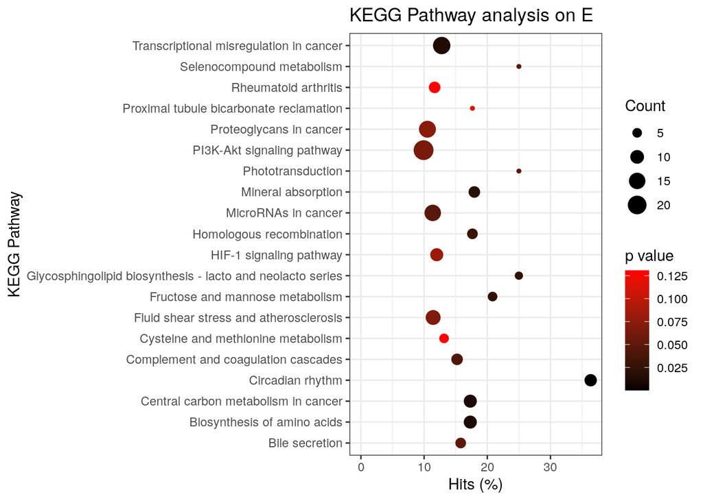

```r
k_E %>% top_n(20, wt=-P.DE) %>% mutate(hits=DE*100/N) %>%
    ggplot(aes(x=hits, y=Pathway, colour=P.DE, size=DE)) +
        geom_point() +
        expand_limits(x=0) +
        labs(x="Hits (%)", y="KEGG Pathway", colour="p value", size="Count") +
  scale_color_gradient(low="black", high="red") +
  ggtitle("KEGG Pathway analysis on E") +
  theme_bw()
```